# Customer Churn Analysis

7/20/2021

## Setup

```r
library(tidyverse)
library(here)
```

## Data Read

```r
churn <- read_csv(here("Data", "churn.csv"))
str(churn)
```

```
## spec_tbl_df[,14] [10,000 × 14] (S3: spec_tbl_df/tbl_df/tbl/data.frame)
##  $ RowNumber      : num [1:10000] 1 2 3 4 5 6 7 8 9 10 ...
##  $ CustomerId     : num [1:10000] 15634602 15647311 15619304 15701354 15737888 ...
##  $ Surname        : chr [1:10000] "Hargrave" "Hill" "Onio" "Boni" ...
##  $ CreditScore    : num [1:10000] 619 608 502 699 850 645 822 376 501 684 ...
##  $ Geography      : chr [1:10000] "France" "Spain" "France" "France" ...
##  $ Gender         : chr [1:10000] "Female" "Female" "Female" "Female" ...
##  $ Age            : num [1:10000] 42 41 42 39 43 44 50 29 44 27 ...
##  $ Tenure         : num [1:10000] 2 1 8 1 2 8 7 4 4 2 ...
##  $ Balance        : num [1:10000] 0 83808 159661 0 125511 ...
##  $ NumOfProducts  : num [1:10000] 1 1 3 2 1 2 2 4 2 1 ...
##  $ HasCrCard      : num [1:10000] 1 0 1 0 1 1 1 1 0 1 ...
##  $ IsActiveMember : num [1:10000] 1 1 0 0 1 0 1 0 1 1 ...
##  $ EstimatedSalary: num [1:10000] 101349 112543 113932 93827 79084 ...
##  $ Exited         : num [1:10000] 1 0 1 0 0 1 0 1 0 0 ...
##  - attr(*, "spec")=
##   .. cols(
##   ..   RowNumber = col_double(),
##   ..   CustomerId = col_double(),
##   ..   Surname = col_character(),
##   ..   CreditScore = col_double(),
##   ..   Geography = col_character(),
##   ..   Gender = col_character(),
##   ..   Age = col_double(),
##   ..   Tenure = col_double(),
##   ..   Balance = col_double(),
##   ..   NumOfProducts = col_double(),
##   ..   HasCrCard = col_double(),
##   ..   IsActiveMember = col_double(),
##   ..   EstimatedSalary = col_double(),
##   ..   Exited = col_double()
##   .. )
```

```r
summary(churn)
```

```
##    RowNumber       CustomerId         Surname           CreditScore
##  Min.   :    1   Min.   :15565701   Length:10000       Min.   :350.0
##  1st Qu.: 2501   1st Qu.:15628528   Class :character   1st Qu.:584.0
##  Median : 5000   Median :15690738   Mode  :character   Median :652.0
##  Mean   : 5000   Mean   :15690941                      Mean   :650.5
##  3rd Qu.: 7500   3rd Qu.:15753234                      3rd Qu.:718.0
##  Max.   :10000   Max.   :15815690                      Max.   :850.0
##   Geography            Gender               Age            Tenure
##  Length:10000       Length:10000       Min.   :18.00   Min.   : 0.000
##  Class :character   Class :character   1st Qu.:32.00   1st Qu.: 3.000
##  Mode  :character   Mode  :character   Median :37.00   Median : 5.000
##                                        Mean   :38.92   Mean   : 5.013
##                                        3rd Qu.:44.00   3rd Qu.: 7.000
##                                        Max.   :92.00   Max.   :10.000
##     Balance       NumOfProducts    HasCrCard      IsActiveMember
##  Min.   :     0   Min.   :1.00   Min.   :0.0000   Min.   :0.0000
##  1st Qu.:     0   1st Qu.:1.00   1st Qu.:0.0000   1st Qu.:0.0000
##  Median : 97199   Median :1.00   Median :1.0000   Median :1.0000
##  Mean   : 76486   Mean   :1.53   Mean   :0.7055   Mean   :0.5151
##  3rd Qu.:127644   3rd Qu.:2.00   3rd Qu.:1.0000   3rd Qu.:1.0000
##  Max.   :250898   Max.   :4.00   Max.   :1.0000   Max.   :1.0000
##  EstimatedSalary         Exited
##  Min.   :    11.58   Min.   :0.0000
##  1st Qu.: 51002.11   1st Qu.:0.0000
##  Median :100193.91   Median :0.0000
##  Mean   :100090.24   Mean   :0.2037
##  3rd Qu.:149388.25   3rd Qu.:0.0000
##  Max.   :199992.48   Max.   :1.0000
```

```r
glimpse(churn)
```

```
## Rows: 10,000
## Columns: 14
## $ RowNumber       <dbl> 1, 2, 3, 4, 5, 6, 7, 8, 9, 10, 11, 12, 13, 14, 15, 16,…
## $ CustomerId      <dbl> 15634602, 15647311, 15619304, 15701354, 15737888, 1557…
## $ Surname         <chr> "Hargrave", "Hill", "Onio", "Boni", "Mitchell", "Chu",…
## $ CreditScore     <dbl> 619, 608, 502, 699, 850, 645, 822, 376, 501, 684, 528,…
## $ Geography       <chr> "France", "Spain", "France", "France", "Spain", "Spain…
## $ Gender          <chr> "Female", "Female", "Female", "Female", "Female", "Mal…
## $ Age             <dbl> 42, 41, 42, 39, 43, 44, 50, 29, 44, 27, 31, 24, 34, 25…
## $ Tenure          <dbl> 2, 1, 8, 1, 2, 8, 7, 4, 4, 2, 6, 3, 10, 5, 7, 3, 1, 9,…
## $ Balance         <dbl> 0.00, 83807.86, 159660.80, 0.00, 125510.82, 113755.78,…
## $ NumOfProducts   <dbl> 1, 1, 3, 2, 1, 2, 2, 4, 2, 1, 2, 2, 2, 2, 2, 2, 1, 2, …
## $ HasCrCard       <dbl> 1, 0, 1, 0, 1, 1, 1, 1, 0, 1, 0, 1, 1, 0, 1, 0, 1, 1, …
## $ IsActiveMember  <dbl> 1, 1, 0, 0, 1, 0, 1, 0, 1, 1, 0, 0, 0, 0, 1, 1, 0, 1, …
## $ EstimatedSalary <dbl> 101348.88, 112542.58, 113931.57, 93826.63, 79084.10, 1…
## $ Exited          <dbl> 1, 0, 1, 0, 0, 1, 0, 1, 0, 0, 0, 0, 0, 0, 0, 0, 1, 0, …
```

## Data Exploration

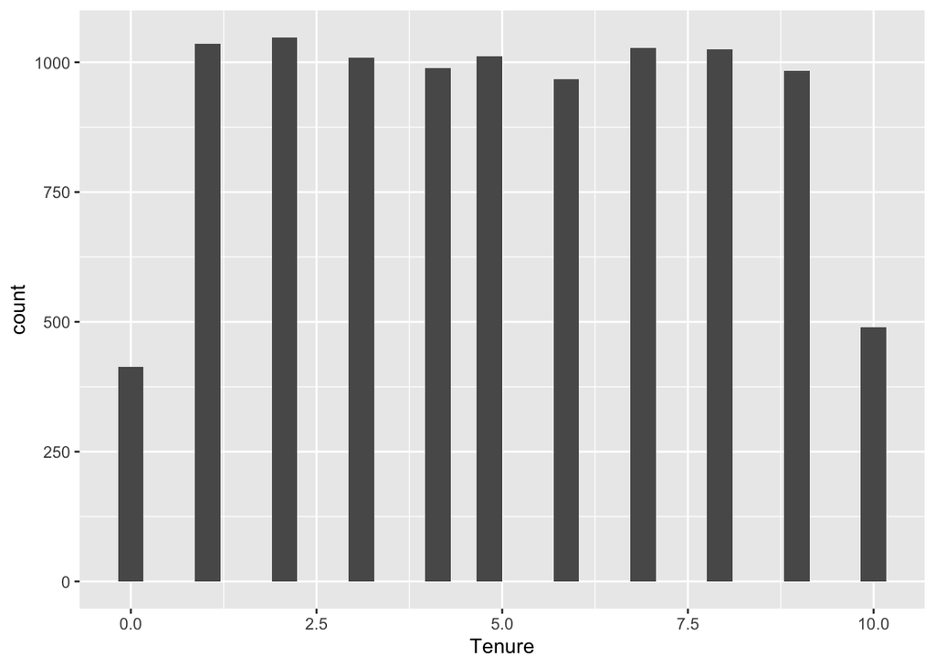

```r
churn %>%
  ggplot() +
  geom_histogram(aes(x = Tenure))
```

```r
## Explore some categorical or discrete variables

churn %>%
  count(Geography)
```

```
## # A tibble: 3 x 2
##   Geography     n
##   <chr>     <int>
## 1 France     5014
## 2 Germany    2509
## 3 Spain      2477
```

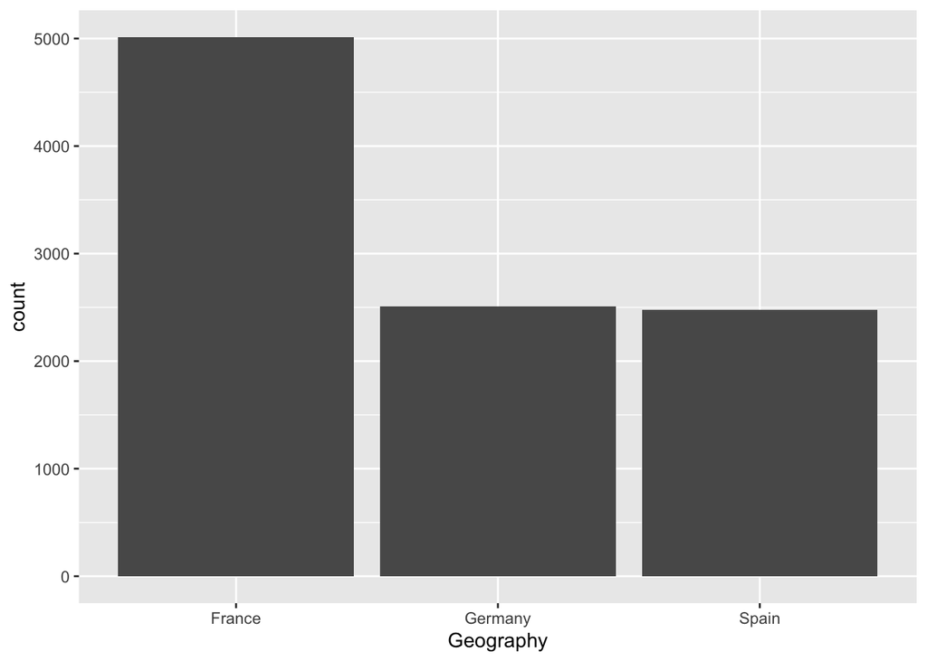

```r
churn %>%
  ggplot() +
  geom_bar(aes(x = Geography))
```

## Data Cleaning

```r
churn <- churn %>%
  mutate(
    Geography = factor(Geography),
    Gender = factor(Gender),
    HasCrCard = factor(HasCrCard,
                       levels = c("0", "1"),
                       labels = c("No", "Yes")),
    IsActiveMember = factor(IsActiveMember,
                       levels = c("0", "1"),
                       labels = c("No", "Yes")),
    Exited = factor(Exited,
                       levels = c("0", "1"),
                       labels = c("No", "Yes")),
  )
```

## Data Summaries

1. What are the mean and median account balances among customers in this dataset?

```r
churn %>%
  summarize(
    mean(Balance),
    median(Balance)
  )
```

```
## # A tibble: 1 x 2
##   `mean(Balance)` `median(Balance)`
##             <dbl>             <dbl>
## 1          76486.            97199.
```

2. What are the mean values of: age, account balance, and salary?

```r
churn %>%
  summarize(
    across(c(Age, Balance, EstimatedSalary),
           list(mean))
  )
```

```
## # A tibble: 1 x 3
##   Age_1 Balance_1 EstimatedSalary_1
##   <dbl>     <dbl>             <dbl>
## 1  38.9    76486.           100090.
```

3. Among customers in the USA, what is the average credit score?

```r
churn %>%
  filter(Geography == "USA") %>%
  summarize(mean(CreditScore))
```

```
## # A tibble: 1 x 1
##   `mean(CreditScore)`
##                 <dbl>
## 1                 NaN
```

Among customers in France, what is the average credit score?

```r
churn %>%
  filter(Geography == "France") %>%
  summarize(mean(CreditScore))
```

```
## # A tibble: 1 x 1
##   `mean(CreditScore)`
##                 <dbl>
## 1                650.
```

4. What country are the customers with the top three highest balances from?

```r
churn %>%
  top_n(3, Balance) %>%
  select(Geography, Balance)
```

```
## # A tibble: 3 x 2
##   Geography Balance
##   <fct>       <dbl>
## 1 Spain     250898.
## 2 France    238388.
## 3 Spain     222268.
```

5. Do the average salaries differ between those with credit cards and those without?

```r
churn %>%
  group_by(HasCrCard) %>%
  summarize(mean(EstimatedSalary))
```

```
## # A tibble: 2 x 2
##   HasCrCard `mean(EstimatedSalary)`
##   <fct>                       <dbl>
## 1 No                        100974.
## 2 Yes                        99721.
```

6. Is there a difference in gender distribution of customers who have exited the bank?

```r
churn %>%
  count(Gender, Exited)
```

```
## # A tibble: 4 x 3
##   Gender Exited     n
##   <fct>  <fct>  <int>
## 1 Female No      3404
## 2 Female Yes     1139
## 3 Male   No      4559
## 4 Male   Yes      898
```

## More Visualization

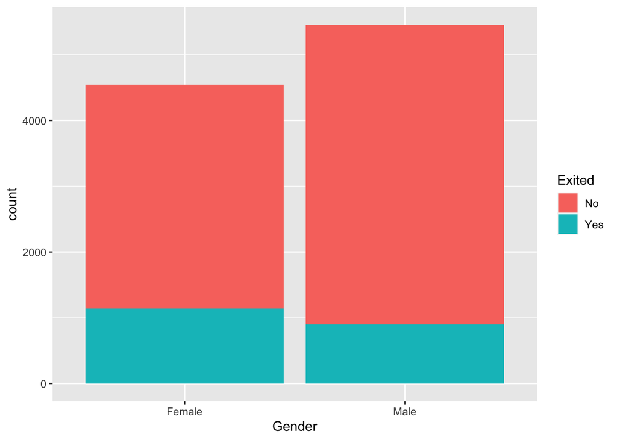

```r
## Comparing categorical variables

churn %>%
  ggplot() +
  geom_bar(aes(x = Gender,
               fill = Exited))
```

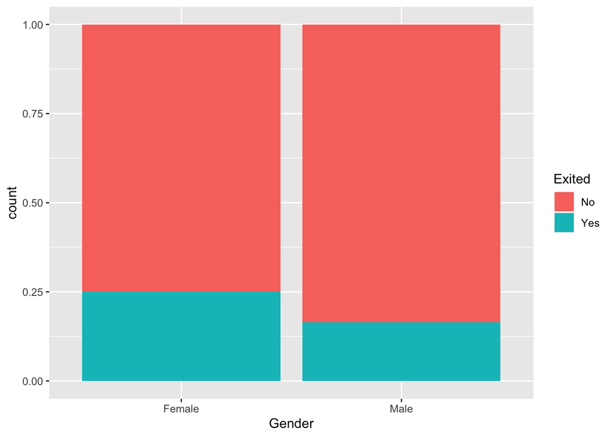

```r
churn %>%
  ggplot() +
  geom_bar(aes(x = Gender,
               fill = Exited),
           position = "fill")
```

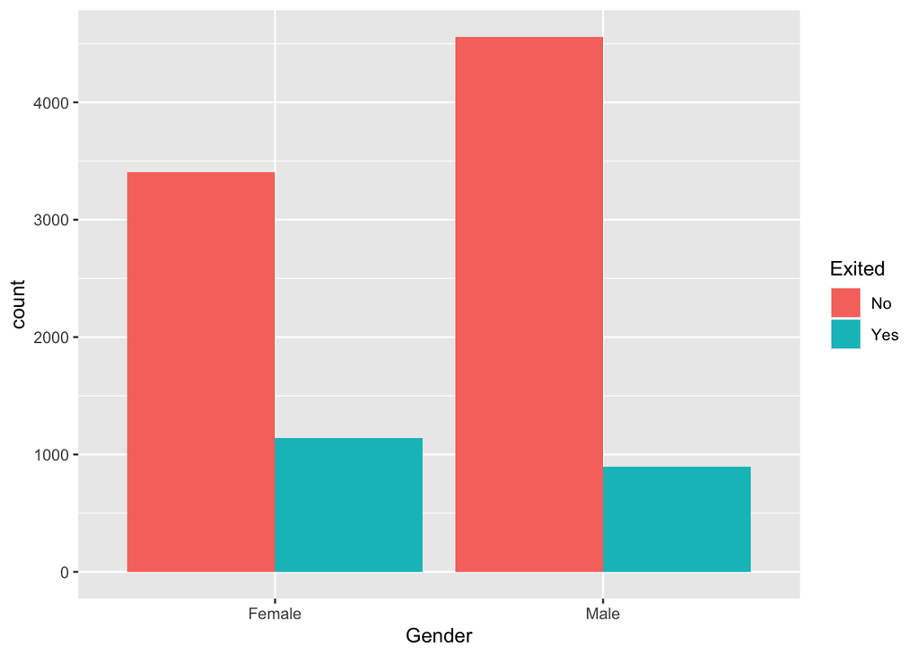

```r
churn %>%
  ggplot() +
  geom_bar(aes(x = Gender,
               fill = Exited),
           position = "dodge")
```

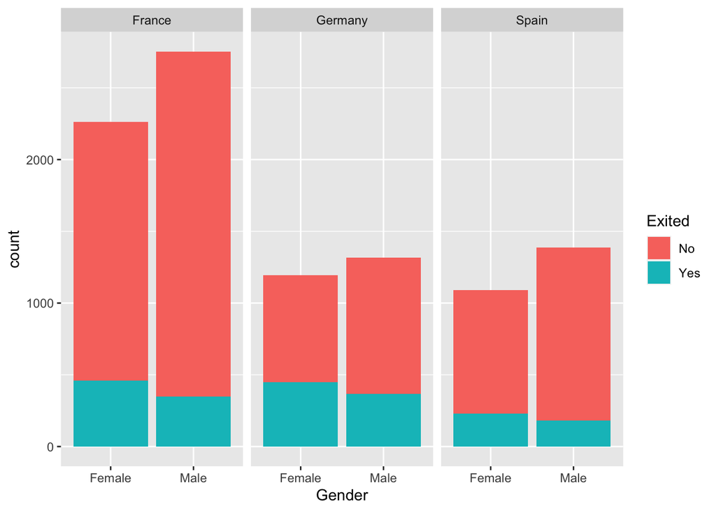

```r
churn %>%
  ggplot() +
  geom_bar(aes(x = Gender,
               fill = Exited)) +
  facet_wrap(~Geography)
```

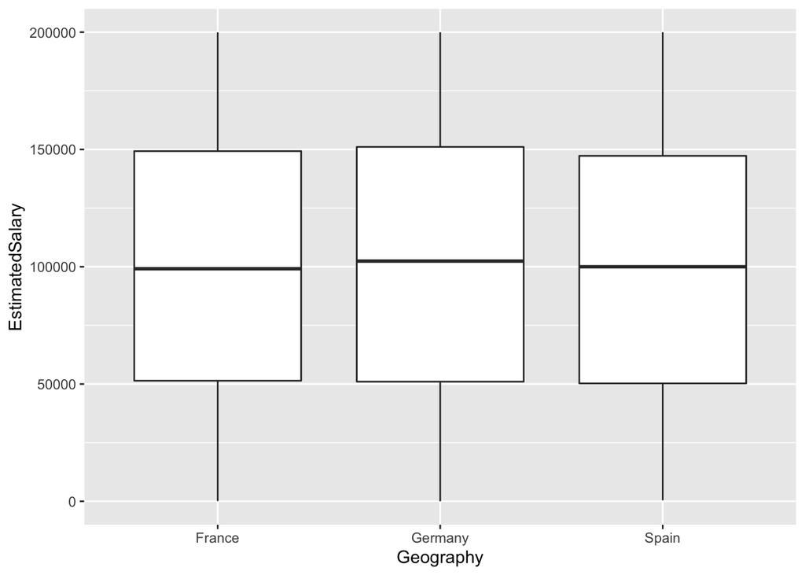

```r
## comparing a categorical and a quantitative

churn %>%
  ggplot() +
  geom_boxplot(aes(x = Geography,
                   y = EstimatedSalary))
```

[figure not shown]

```r
churn %>%
  ggplot() +
  geom_density(aes(x = Geography,
                   y = EstimatedSalary),
               alpha = 0.5)
```

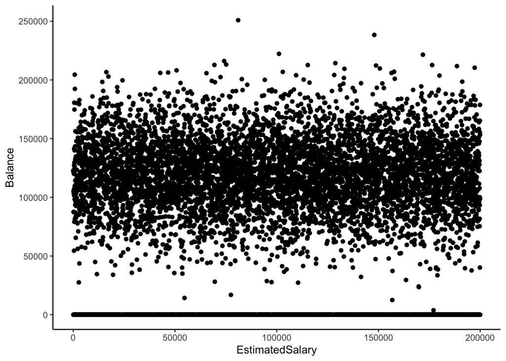

```r
churn %>%
  ggplot() +
  geom_point(aes(x = EstimatedSalary,
                   y = Balance)) +
  theme_classic()
```

## Pivoting

1. Find the average salary of each gender in each country.

```r
sal_by_country <- churn %>%
  group_by(Gender, Geography) %>%
  summarize(
    mean_sal = mean(EstimatedSalary)
  )
sal_by_country
```

```
## # A tibble: 6 x 3
## # Groups:   Gender [2]
##   Gender Geography mean_sal
##   <fct>  <fct>        <dbl>
## 1 Female France      99564.
## 2 Female Germany    102446.
## 3 Female Spain      100734.
## 4 Male   France     100174.
## 5 Male   Germany     99905.
## 6 Male   Spain       98426.
```

2. Pivot your data frame from (1) so that there is one column for each gender identity.

```r
sal_by_country <- sal_by_country %>%
  pivot_wider(
    names_from = Gender,
    values_from = mean_sal,
    names_prefix = "av_sal_"
  )

sal_by_country
```

```
## # A tibble: 3 x 3
##   Geography av_sal_Female av_sal_Male
##   <fct>             <dbl>       <dbl>
## 1 France           99564.     100174.
## 2 Germany         102446.      99905.
## 3 Spain           100734.      98426.
```

3. Create a new column showing the difference between female-identifying and male-identifying average salaries.

```r
sal_by_country <- sal_by_country %>%
  mutate(
    sal_diff = av_sal_Male - av_sal_Female
  )
```

## Joining

Repeat the above, this time for balances rather than salaries.

```r
bal_by_country <- churn %>%
  group_by(Gender, Geography) %>%
  summarize(
    mean_bal = mean(Balance)
  ) %>%
   pivot_wider(
    names_from = Gender,
    values_from = mean_bal,
    names_prefix = "av_bal_"
  ) %>%
  mutate(
    bal_diff = av_bal_Male - av_bal_Female
  )
```

Join the two datasets by country name.

```r
sal_by_country %>%
  full_join(bal_by_country)
```

```
## # A tibble: 3 x 7
##   Geography av_sal_Female av_sal_Male sal_diff av_bal_Female av_bal_Male
##   <fct>             <dbl>       <dbl>    <dbl>         <dbl>       <dbl>
## 1 France           99564.     100174.     610.        60323.      63546.
## 2 Germany         102446.      99905.   -2541.       119146.     120260.
## 3 Spain           100734.      98426.   -2308.        59862.      63353.
## # … with 1 more variable: bal_diff <dbl>
```

## Your own analysis

Choose one of the following research questions to address with a beautiful plot (or make up your own). Write up your results in a **new** R Markdown file, in your **new** project.

- How does the relationship between age and churn (exit) differ by gender/country?
- Is a customer with a credit card considered “desirable”? For example, do they stay with the bank longer? Are they less likely to exit? Do they use more bank products?
- How does age impact customer behavior? That is, is the impact of other qualities (balance, salary, etc) on customer tenure and/or churn different across ages?